# Causal models for qualitative and mixed methods inference

Lecture 2: Queries and inferences

Macartan Humphreys and Alan Jacobs

# 1 Queries

## 1.1 Estimands (causal questions)

Estimands are the things you want to know.

A few common causal estimands:

- Case-level causal effects
  - e.g., Did/does $X$ have a positive effect on $Y$ in this case?
  - e.g., Did $X=1$ cause $Y=1$ in this case with $X=1, Y=1$?
- Causal pathways
  - e.g., Does $X$ affect $Y$ through $M$?
    - For this case?
    - For population as a whole?
- Average causal effects for a population
  - e.g., What is the average effect of $X$ on $Y$

## 1.2 Case-level causal effects

- In qualitative research, we often see an outcome and want to know what caused it
  - Why does $Y=1$ in this case?
  - Why did Argentina democratize in the 1980s?
- And we have suspected causes?
  - Did $X=1$ cause $Y=1$ in this case?
  - Did $W=1$ cause $Y=1$ in this case?
  - Did military defeat cause Argentina’s democratization?
- “Did $X=1$ cause $Y=1$ in this case?” means (in a binary framework)….
  - If $X$ had been $0$ in this case, **would $Y$ have been $0$?**
- “Did military defeat cause Argentina’s democratization?” means….
  - If military defeat had not happened, would Argentina’s democratization failed to happen?

## 1.3 The probability of a case-level causal effect

- We can express case-level causal effects queries as questions about **probabilities**
  - “Did $X=1$ cause $Y=1$ in this case?” is not a yes/no question
- We need to ask, what is the **probability** that $X=1$ caused $Y=1$ in this case?
  - Probability of causation
- We always **condition** this question on what we already know about the case
  - Given that $X=1$ and $Y=1$ in this case, what’s the probability that $X=1$ caused $Y=1$?
  - Given that Argentina experienced military defeat and democratized, what’s the probability that former caused the latter?

## 1.4 Case-level causal effects and nodal types

- “Did $X=1$ cause $Y=1$ in this case?” means (in a binary framework)….
  - If $X$ had been $0$ in this case, **would $Y$ have been $0$?**
- This is the **same** as asking: is the case a $\theta_{01}$ type?
  - This is a type in which
    - $Y=1$ if $X=1$
    - $Y=0$ if $X=0$
- More precisely we ask, what’s the probability that this case is a $\theta^{01}$ type?

## 1.5 Causal queries on a DAG

*Causal queries can be expressed as nodes on a causal graph*

## 1.6 Causal queries on a DAG: case-level causal effect

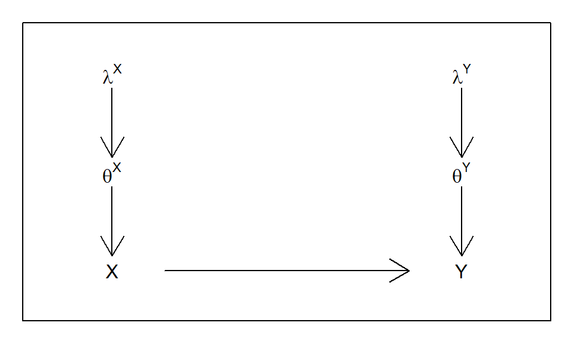

- Does $X$ have a positive effect on $Y$ in this case?
  - This is a question about the value of $\theta^Y$
- Does $\theta^Y = \theta^Y_{01}$? (Or what’s the probability of that?)

## 1.7 Pathway questions

- How did $X$ cause $Y$ in this case?
  - What is the pathway or mechanism?
- We might think there’s a *possible* pathway through $M$, but did that pathway actually operate in this case?
- There could be other possibilities
- Did military defeat cause democratization in Argentina through creating division within the army?
  - Or did military defeat cause democratization in Argentina through generating popular protest?
- Also a question about nodal types

## 1.8 Causal queries on a DAG: pathway questions

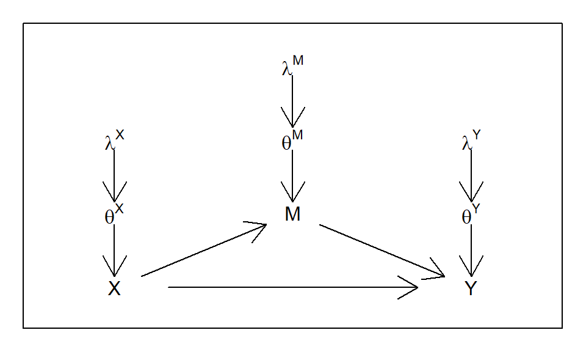

- Does $X$ have a positive effect on $Y$ through $M$ in this case?
- A question about $\theta^M$ and $\theta^Y$ in this case

## 1.9 Causal queries on a DAG: pathway questions

- A question about $\theta^M$
  - Does $M$ respond to $X$?
  - E.g., is $\theta^M = \theta_{01}^M$?
- Questions about $\theta^Y$
  - When $M$ changes the way it does when $X$ goes from 0 to 1, does $Y$ go from 0 to 1, **even when $X$ is held constant**?
  - Does $Y$ increase if $X$ increases **but $M$ is held constant**?
- We work through this in the “Causal Questions” chapter, but larger point:
  - We can define this causal question (like any causal question) as a question about combinations of nodal types (i.e., causal types)

## 1.10 Causal queries with conditioning

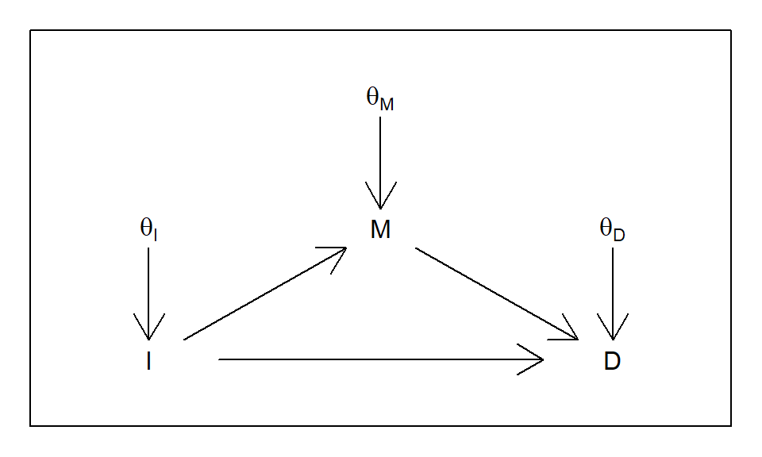

- We can ask: what is the effect of $X$ on $Y$ given $M=1$?
- Importantly, different from: what is the effect of $X$ on $Y$ if $M$ is *set* to $1$?

## 1.11 Why bother? Why define causal questions on a DAG?

- We are turning our questions into nodes on a graph
- The key is: **We can learn about nodes if we have information on other nodes they’re connected to**
- If we know $X$, $M$, and $Y$ in a case, we can draw inferences about $\theta^M$ and $\theta^Y$ for this case
- This is, at an intuitive level, what `CausalQueries` does

## 1.12 Lotsa queries

| Model | Query | Given | Interpretation | Types |
| --- | --- | --- | --- | --- |
| X -> Y | Y[X=1] > Y[X=0] |  | Probability that X has a positive effect on Y | X0.Y01, X1.Y01 |
| X -> Y | Y[X=1] < Y[X=0] | X == 1 | Probability that X has a negative effect on Y among those for whom X=1 | X1.Y10 |
| X -> Y | Y[X=1] > Y[X=0] | X==1 & Y==1 | Probability that Y=1 is due to X=1 (Attribution) | X1.Y01 |
| X -> Y <- W | Y[X=1] > Y[X=0] | W == 1 | Probability that X has a positive effect on Y for a case in which W = 1 (where W is possibly defined post treatment) | W1.X0.Y0001, W1.X1.Y0001, W1.X0.Y1001, W1.X1.Y1001, W1.X0.Y0011, W1.X1.Y0011, W1.X0.Y1011, W1.X1.Y1011 |
| X -> Y <- W | Y[X=1, W = 1] > Y[X=0, W = 1] | W==0 | Probability that X has a positive effect on Y if W were set to 1 for cases for which in fact W=0 | W0.X0.Y0001, W0.X1.Y0001, W0.X0.Y1001, W0.X1.Y1001, W0.X0.Y0011, W0.X1.Y0011, W0.X0.Y1011, W0.X1.Y1011 |
| X -> Y <- W | Y[X=1] > Y[X=0] | Y[W=1] > Y[W=0] | Probability that X has a positive effect on Y for a case in which W has a positive effect on Y | W0.X0.Y0110, W1.X1.Y0001, W1.X1.Y1001, W0.X0.Y0111 |
| X -> Y <- W | (Y[X=1, W = 1] > Y[X=0, W = 1]) > (Y[X=1, W = 0] > Y[X=0, W = 0]) | W==1 & X==1 | Probability of a positive interaction between W and X for Y; the probability that the effect of X on Y is stronger when W is larger | W1.X1.Y0001, W1.X1.Y1001, W1.X1.Y1011 |
| X -> M -> Y <- X | Y[X = 1, M = M[X=1]] > Y[X = 0, M = M[X=1]] | X==1 & M==1 & Y==1 | The probability X would have a positive effct on Y if M were controlled to be at the level it would take if X were 1 for units for which in fact M==1 | X1.M01.Y0001, X1.M11.Y0001, X1.M01.Y1001, X1.M11.Y1001, X1.M01.Y0101, X1.M11.Y0101, X1.M01.Y1101, X1.M11.Y1101 |
| X -> M -> Y <- X | (Y[M = 1] > Y[M = 0]) & (M[X = 1] > M[X = 0]) | Y[X=1] > Y[X=0] & M==1 | The probability that X causes M and M causes Y among units for which M = 1 and X causes Y | X1.M01.Y0001, X1.M01.Y0011 |

# 2 Updating

# 3 Bayesian approaches

*Updating on causal quantities*

## 3.1 Outline

1. Bayesian reasoning
2. Bayesian calculations by hand

## 3.2 Bayes reasoning

- Bayesian methods are just sets of procedures to figure out how to update beliefs in light of new information.
- We begin with a prior belief about the probability that a hypothesis is true.
- New data then allow us to form a posterior belief about the probability of the hypothesis.

### 3.2.1 Bayes Rule

Bayesian inference takes into account:

- the consistency of the evidence with a hypothesis
- the uniqueness of the evidence to that hypothesis
- background knowledge about the problem.

### 3.2.2 Illustration 1

I draw a card from a deck and ask *What are the chances it is a Jack of Spades?*

- Just 1 in 52.

Now I tell you that the card is indeed a spade. What would you guess?

- 1 in 13

What if I told you it was a heart?

- No chance it is the Jack of Spades

What if I said it was a face card and a spade.

- 1 in 3.

### 3.2.3 Illustration 1

These answers are applications of Bayes’ rule.

In each case the answer is derived by assessing what is possible, given the new information, and then assessing how likely the outcome of interest among the states that are possible. In all the cases you calculate:

$$\text{Prob Jack of Spades | Info} = \frac{\text{Is Jack of Spades Consistent w/ Info?}}{\text{How many cards are consistent w/ Info?}}$$

### 3.2.4 Illustration 2 **Interpreting Your Test Results**

You take a test to see whether you suffer from a disease that affects 1 in 100 people. The test is good in the following sense:

- if you have the disease, then with a 99% probability it will say you have the disease
- if you do not have it, then with a 99% probability, it will say that you do not have it

The test result says that you have the disease. What are the chances you have it?

### 3.2.5 Illustration 2 **Interpreting Your Test Results**

- It is *not* 99%. 99% is the probability of the result given the disease, but we want the probability of the disease given the result.
- The right answer is 50%, which you can think of as the share of people that have the disease among all those that test positive. For example
- e.g. if there were 10,000 people, then 100 would have the disease and 99 of these would test positive. But 9,900 would not have the disease and 99 of these would test positive. So the people with the disease that test positive are half of the total number testing positive.

### 3.2.6 Illustration 2. A picture

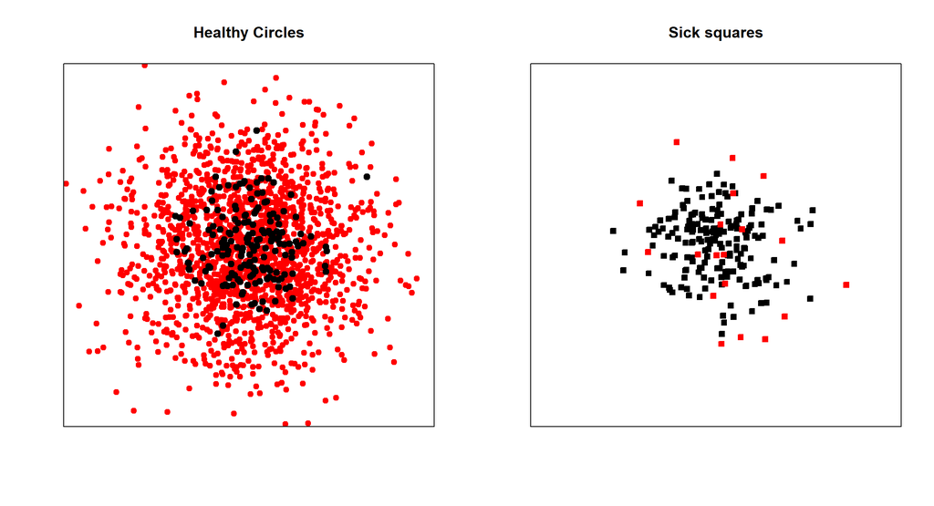

What’s the probability of being a circle given you are black?

### 3.2.7 Illustration 2. More formally.

As an equation this might be written:

$$\text{Prob You have the Disease | Pos} = \frac{\text{How many have the disease and test pos?}}{\text{How many people test pos?}}$$

### 3.2.8 Two Child Problem

- Mr Smith has two children, $A$ and $B$.
- At least one of them is a boy.
- What are the chances they are both boys?

To be explicit about the puzzle, we will assume that the information that one child is a boy is given as a truthful answer to the question “*is at least one of the children a boy?*”

Assuming also that there is a 50% probability that a given child is a boy.

### 3.2.9 Two Child Problem

As an equation:

$$\text{Prob both boys | Not both girls} = \frac{\text{Prob both boys}}{\text{Prob not both girls}} = \frac{\text{1 in 4}}{\text{3 in 4}}$$

### 3.2.10 Monty Hall

Can anyone describe the Monty Hall puzzle?

### 3.2.11 Bayes Rule

Formally, all of these equations are applications of Bayes’ rule which is a simple and powerful formula for deriving updated beliefs from new data.

The formula is given as:

$$\Pr(H|\mathcal{D})=\frac{\Pr(\mathcal{D}|H)\Pr(H)}{\Pr(\mathcal{D})}\\
=\frac{\Pr(\mathcal{D}|H)\Pr(H)}{\sum_{H'}\Pr(\mathcal{D}|H')\Pr(H'))}$$

### 3.2.12 Bayes Rule

Formally, all of these equations are applications of Bayes’ rule which is a simple and powerful formula for deriving updated beliefs from new data.

For continuous distributions and parameter vector $\theta$:

$$p(\theta|\mathcal{D})=\frac{p(\mathcal{D}|\theta)p(\theta)}{\int_{\theta'}p(\mathcal{D|\theta'})p(\theta')d\theta}$$

### 3.2.13 Illustration of continuous distributions

Consider **the share of people in a population that voted** or **the share of people for which there is a positive treatment effect*

- This is a quantity between 0 and 1.
- It can be represented by a continuous distribution: the beta distribution, with parameters that reflect how much data you have observed

### 3.2.14 Beta

- The Beta distribution is a distribution over the $[0,1]$ that is governed by two parameters, $\alpha$ and $\beta$.
- In the case in which both $\alpha$ and $\beta$ are 1, the distribution is uniform – all values are seen as equally likely.
- As $\alpha$ rises large outcomes are seen as more likely
- As $\beta$ rises, lower outcomes are seen as more likely.
- If both rise proportionately the expected outcome does not change but the distribution becomes tighter.

An attractive feature is that if one has a prior Beta($\alpha$, $\beta$) over the probability of some event, and then one observes a positive case, the Bayesian posterior distribution is also a Beta with with parameters $\alpha+1, \beta$. Thus if people start with uniform priors and build up knowledge on seeing outcomes, their posterior beliefs should be Beta.

### 3.2.15 Beta

Here is a set of such distributions.

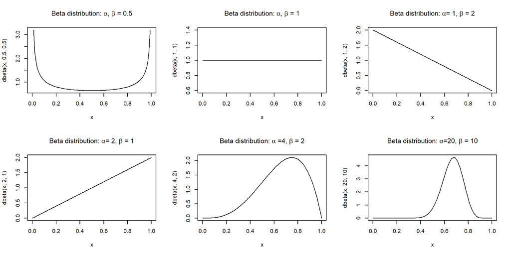

Beta distributions

## 3.3 Bayes “by hand”

*Bayes on a Grid*

### 3.3.1 Bayes by hand

- The simplest and most intuitive way to do Bayesian estimation is just to apply the formula over a grid of possible values
- This becomes too hard once your parameter space grows but it is worth working though the logic by hand to get a feel for Bayes

### 3.3.2 Bayes by hand

- Lets say that we want to figure out the share of women in some population.
- We start off with a flat prior over all possible numbers
- We draw a sample from the population: 100 people of which 20 are women
- What’s our posterior?

### 3.3.3 Bayes by hand

```r
fabricate(N = 100,
          parameters = seq(.01, .99, length = N),
          likelihood = dbinom(20, 100, parameters),
          posterior = likelihood/sum(likelihood)) |>
  ggplot(aes(parameters, posterior)) + geom_line() + theme_bw()
```

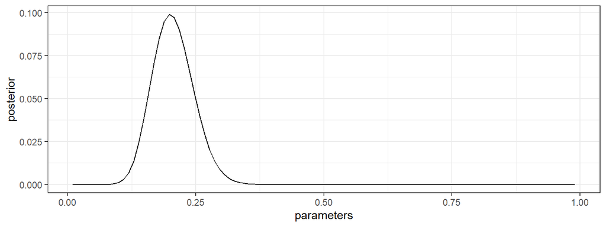

### 3.3.4 Bayes by hand

Now with a strongish prior on 50%:

```r
fabricate(N = 100,
          parameters = seq(.01, .99, length = N),
          prior = dbeta(parameters, 20, 20),
          prior = prior/sum(prior),
          likelihood = dbinom(20, 100, parameters),
          posterior = likelihood*prior/sum(likelihood*prior)) |>
  ggplot(aes(parameters, posterior)) + geom_line() + theme_bw() +
  geom_line(aes(parameters, prior), color = "red")
```

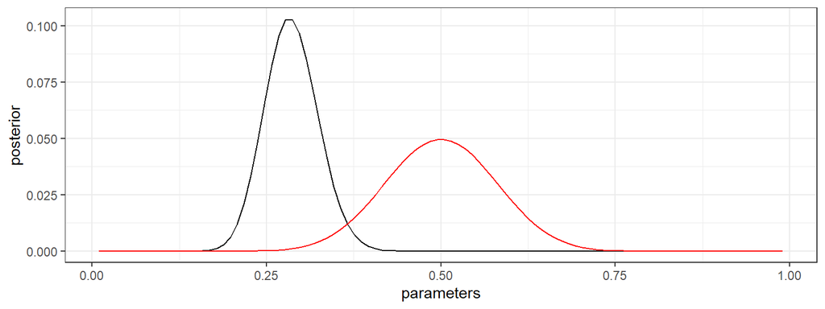

### 3.3.5 Bayes by hand

- This approach is sound, but if you are dealing with many continuous parameters, the full parameter space can get very large and so the number of calculations you do increases rapidly.
- Luckily other approaches have been developed.

# 4 Conditional independence

*Figuring out when A tells you something about B*

## 4.1 Key insight linking DAGs to Bayes

The key insight that connects a DAG representation of a causal model and Bayesian updating is this:

- the DAG can tell you how to update on one feature given informmation on another

## 4.2 Key insight linking DAGs to Bayes

Most simple idea.

Say we have DAG: $X \rightarrow Y$ and we know:

- $Pr(X = 1) = .5$
- $Pr(Y = 1 | X = 1) = .75$
- $Pr(Y = 1 | X = 0) = .25$

Then we can ask a question like: what is the probability that $X=1$ if indeed $Y=1$:

$$\Pr(X = 1 | Y = 1) = \frac{\Pr(Y = 1 | X = 1)\Pr(X=1)}{\Pr(Y=1)} = \frac{0.75 \times 0.5}{0.5} = 0.75$$

So we can *sometimes* learn about one node from others nodes, up and down a graph.

Let’s figure out *when* we can do this.

## 4.3 Conditional independence and graph structure

- What DAGs do is tell you when one variable is independent of another variable given some third variable.
- Intuitively:
  - what variables “shield off” the influence of one variable on another
  - e.g. If inequality causes revolution *via* discontent, then inequality and revolution should be related to each other overall, but *not* related to each other *among those* that are content or *among those* that are discontent

### 4.3.1 Conditional independence

Variable sets $A$ and $B$ are conditionally independent, given $C$ if for all $a$, $b$, $c$:

$$\Pr(A = a | C = c) = \Pr(A = a | B = b, C = c)$$

Informally; given $C$, knowing $B$ tells you nothing more about $A$.

### 4.3.2 Conditional independence on paths graphs

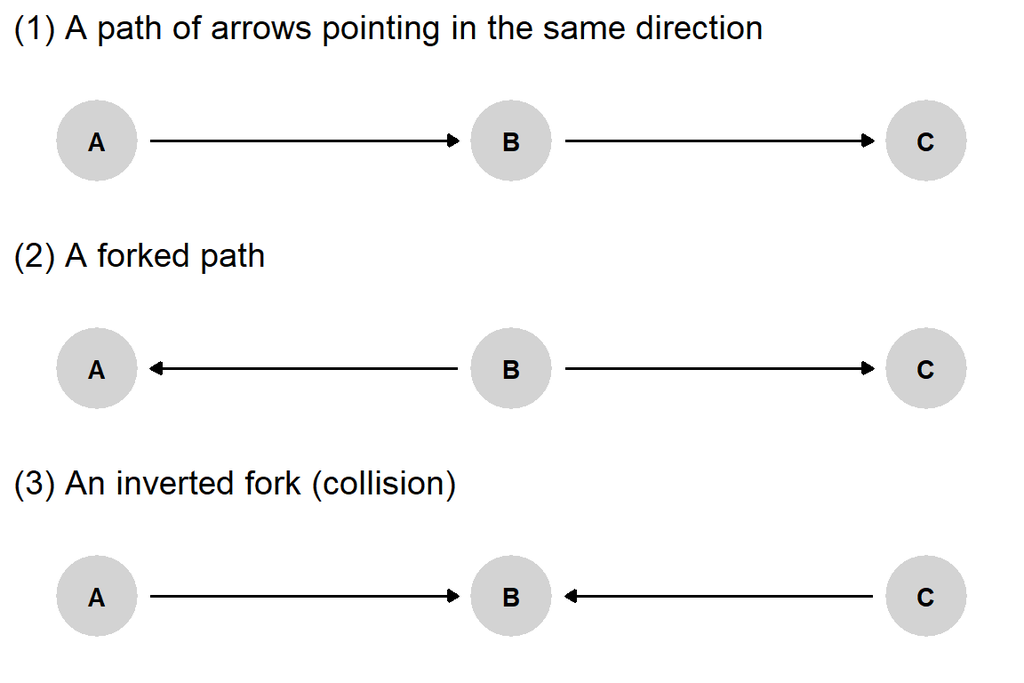

Three elemental relations of conditional independence.

### 4.3.3 Conditional independence from graphs

$A$ and $B$ are *conditionally independent*, given $C$ if on *every* path between $A$ and $B$:

- there is some chain ($\bullet\rightarrow \bullet\rightarrow\bullet$ or $\bullet\leftarrow \bullet\leftarrow\bullet$) or fork ($\bullet\leftarrow \bullet\rightarrow\bullet$) with the central element in $C$,

or

- there is an inverted fork ($\bullet\rightarrow \bullet\leftarrow\bullet$) with the central element (and its descendants) *not* in $C$

Notes:

- In this case we say that $A$ and $B$ are d-separated by $C$.
- $A$, $B$, and $C$ can all be sets
- Note that a path can involve arrows pointing any direction $\bullet\rightarrow \bullet\rightarrow \bullet\leftarrow \bullet\rightarrow\bullet$

### 4.3.4 Test yourself

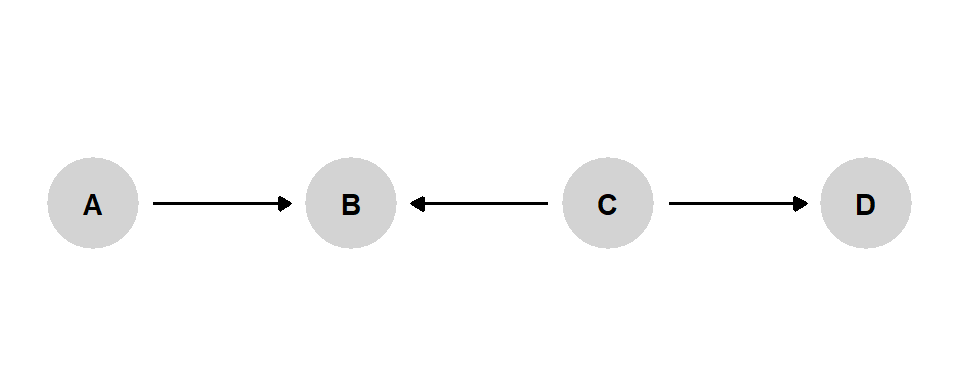

Are A and D unconditionally independent:

- if you do not condition on anything?
- if you condition on B?
- if you condition on C?
- if you condition on B and C?

## 4.4 Theorem

Key insight for process tracing:

- If $K$ is *not* conditionally independent of $Q$ then $K$ *is* informative for $Q$.
- If $K$ *is* conditionally independent of $Q$ then $K$ is *not* for $Q$.

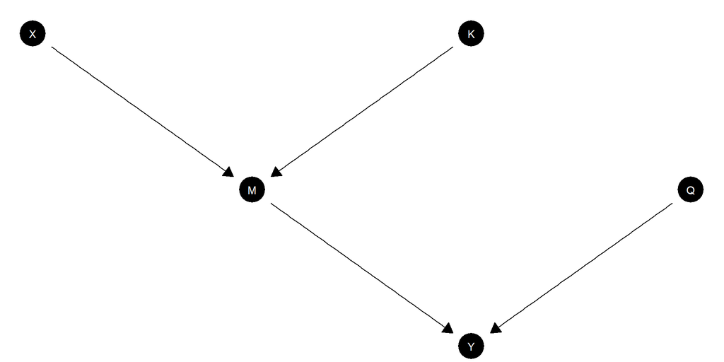

### 4.4.1 Next steps

When we turn to process tracing we will unpack the usefulness of this result

# 5 Updating in `CausalQueries`

*`CausalQueries` brings these elements together*

### 5.0.1 Big picture

`CausalQueries` brings these elements together by allowing users to:

1. Make model: Specify a DAG: `CausalQueries` figures out all principal strata and place probabilities on these (parameters)
2. Query model: `CausalQueries` figures out which parameters correspond to a given causal query

### 5.0.2 Illustration 1

```r
model <- make_model('X -> M -> Y') |>
  set_restrictions(decreasing("X", "M"))

model |>
  query_model(
    query = "Y[X=1] != Y[X=0]",
    given = c("X==1 & Y ==1",
              "M==0",
              "M==1",
              "X==1 & Y ==1 & M==0",
              "X==1 & Y ==1 & M==1"),
    using = "parameters"
)
```

```
Causal queries generated by query_model (all at population level)

|label                                      |using      |  mean|
|:------------------------------------------|:----------|-----:|
|Y[X=1] != Y[X=0] given X==1 & Y ==1        |parameters | 0.167|
|Y[X=1] != Y[X=0] given M==0                |parameters | 0.167|
|Y[X=1] != Y[X=0] given M==1                |parameters | 0.167|
|Y[X=1] != Y[X=0] given X==1 & Y ==1 & M==0 |parameters | 0.000|
|Y[X=1] != Y[X=0] given X==1 & Y ==1 & M==1 |parameters | 0.250|
```